# Brownlows Bets

Deniss Gonzalez Ramirez

2021-11-24

# 1 Introduction

At the first day of class there are 35 students in Math Statistics class and professor Brownlow always proposes this bet to his students “I will wager $2 to your bet of $1 that at least two people in today’s class have the same birthday. He tells me he has made that bet 637 times so far. Where do you think his profits are? Discuss this in a markdown document

Report git commit structure: There are 3 questions and there should be at least 3 separate commits, at least one dealing with each of the 3 questions. 1. What are the fair odds for a bet on matching birthdays in a 35 person class. 2. For what size class is a 2:1 odds bet fair. 3. How much money would Brownlow be expected to end up with if the bets went as described.

## 1.1 Our strategy is to build a Function and the use it to answer the three questions.

The function will be given a class_size by number of students, odds, and Number_of_times brownlow made the bet. It will give you back how much Brownlows earnings were. We will use it to answer our three questions below. If you can, improve this function by giving default values to some of its inputs.

# 2 In the class and payoff as described If you highered 40 brownlow substitute teachers to do the same thing that Brownlow did then.

The code block below explains that the array has 1000 elements inside of it. Each element of the array Data1 represents how much a brownlow gave 2:1 odds and made 637 bets made as a profit. Had this been done 1000 times is what is depicted below. The data also had to be sorted from low to high in order to determine the 95% confidence level and to determine what odds were the most profitable. The middle of it runs from 25 and 975.

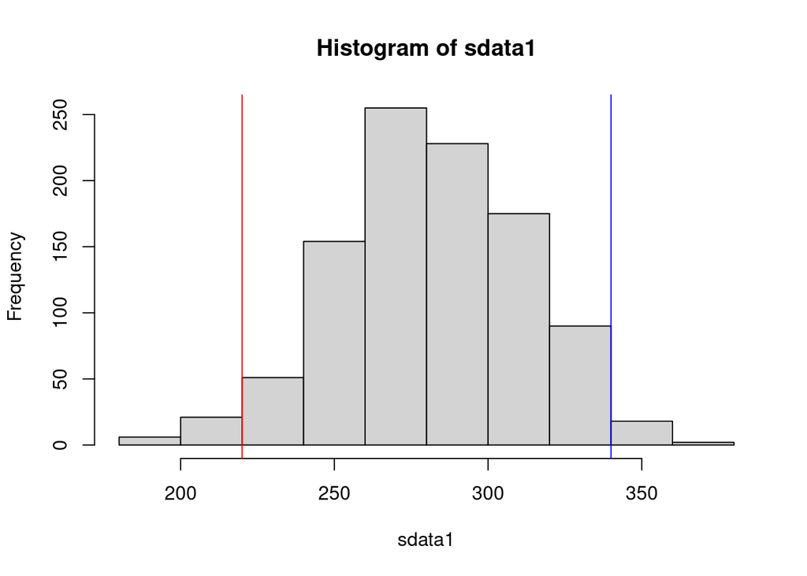

```r
Data1<-array(dim = 1000)
Data1<-as.numeric(Data1)
for(i in 1:1000){
  Data1[i] = deniss()
}
sdata1<-sort(Data1)
hist(sdata1)
abline(v=sdata1[25],col="red")
abline(v=sdata1[975],col="blue")
```

```r
low<-sdata1[25]
high<-sdata1[975]
```

We determined that 40 brownlows was not enough so the test was configured to have 1000 elements. This would provide sufficient evidence The 95% confidence interval is 220 to 340